# NYC Socrata Portal Analyis

This notebook examines some meta-statistics on the datasets on the NYC Socrata portal. It uses a handful of functions from the `socrata-reducer` library, written for this purpose.

## Part I: Defining Datasets

### Socrata

**Socrata** is a late-stage privately held startup (which may go to IPO any day now) which maintains the Socrata Portal, an interface for hosting open data on the web. The [New York City Open Data Portal](https://nycopendata.socrata.com/) runs off of a Socrata instance, as do many others; in fact I would go so far as to say that Socrata has a dominent lead in both market and mind share amongst open data practitioners and offices in the United States (for a survey of all of them, check out http://opendatainception.io/).

### Endpoints and the Portal/Catalog

An **endpoint** is any unique URI hash hosted by Socrata. This includes all of the datasets we host as well as a large variety of other static resources—things like charts, external links, etcetera. Basically endpoints are "everything", insofar as everything is searchable. The set of all endpoints on an open data portal is known within Socrata as a **catalog**; here we tend to refer to it as a **portal**.

[This Socrata support article](https://support.socrata.com/hc/en-us/articles/202949778-Navigating-the-dataset-catalog) states the following endpoint types:

> The dataset catalog is typically the first thing you see on a Socrata site, so what does everything mean on the catalog page?

> [...]

> Datasets: These are datasets uploaded into the Socrata platform.

> External Datasets: links to datasets stored elsewhere on the web.

> Files and Documents: downloadable files such as PDFs or Word documents

> Filtered Views: These are saved filtered Datasets. This is a view of a the type Dataset, and will be linked to the original Dataset through the "More Views" tab.

> Charts: Charts such as pie charts and bar charts created from Datasets. These will also be linked to the original Dataset through the "More Views" tab.

> Maps: Maps created from geolocation data or geospatial data (shapefile, kml, or kmz file). If it is based on geolocation data, it will also be linked to the original Dataset through the "More Views" tab.

> Calendars: Calendars created from Date&Time data in a Dataset. These will be linked to the original Dataset through the "More Views" tab.

> Forms: Forms are created from a Dataset, to collect information from users. These will be linked to the original Dataset through the "More Views" tab.

You can count endpoints by spooling queries against the [Socrata Catalog API](http://labs.socrata.com/docs/search.html). As of writing there are 8145 of them.

### What is a dataset?

Within the Socrata UI a **dataset** is a piece of open data content, uploaded as a delimited file (`csv`, `tbv`, `xls`, etc.), which is converted by Socrata to and is suitable for display using Socrata's most familiar kind of interface, its spreadsheet format. A good example is the NYPD Motor Vehicle Collision dataset ([link](https://data.cityofnewyork.us/Public-Safety/NYPD-Motor-Vehicle-Collisions/h9gi-nx95)):

```python
from IPython.display import Image
```

[figure not shown]

```python
Image("NYPD Motor Vehicle Collision Dataset - Socrata View.png")
```

You can count these **tables** using the catalog API easily, too, by asking for entries where the `type` field is set to `dataset`. This tells me that, as of writing, there are 1073 of them.

But wait, when you hover over the little icon in the top left corner it tells you it's a...table?

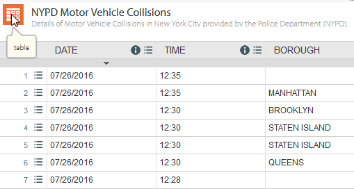

```python
Image("NYPD Motor Vehicle Collision Dataset - Table Tooltip Hover.png")
```

And look at the NYPD page again—do you see the big banner declaring that there are 1500+ datasets?

[figure not shown]

```python
Image("NYPD Motor Vehicle Collision Dataset - Banner.png")
```

One more count. Every Socrata portal has a Site Analytics page which provides a range of interesting tidbits about the portal ([here's New York's](https://nycopendata.socrata.com/analytics)). One of the entries on this page is still another data set counter, with still another number attached to it:

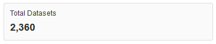

```python
Image("NYC Open Data - Site Analytics Dataset Count.png")
```

Ok what they hey? I reached out to Socrata for clarification. First, the site analytics page:

> The "total datasets" count on the site analytics page includes all published and unpublished tabular datasets created by uploading a data file (e.g. csv, xls,...etc.) and all published and unpublished datasets created by uploading geospatial files including KML / KMZ or shapefiles. These include public as well as private datasets.

Aha! In other words, 2,360 is the number of published *or* unpublished, public *or* private, tabular *or* geospatial data resources on the entire portal. Uh. Some more semantics. Socrata allows individual users to create accounts on an open data portal, and those individual accounts are given the ability to upload their own resources and to manipulate existing ones (by creating derived views, maps, charts, and other somesuch). You can choose whether you want what you upload something publicly or sandbox is privately ([here's what Socrata has to say about it](https://support.socrata.com/hc/en-us/articles/202950198-How-do-Private-Datasets-Work-What-are-my-Limitations-)). If you want a resource to not only be public, but also part of the main site index, you have to publish it (or, more accurately, have it published by a site administrator; [more info here](https://support.socrata.com/hc/en-us/articles/202950228-How-Dataset-Routing-Approval-Works)).

[Socrata's support website also has a longer article on the subject](https://support.socrata.com/hc/en-us/articles/215811017-Determine-Total-Dataset-Count), which notes, in really small text at the bottom of the page:

```python
Image("Socrata Totals Discrepency Comment.png")
```

[output not shown]

But the gist of it is simple—tables and geospatial files, site-wide. Got it.

I've already counted datasets (albeit only public, published ones). Is there a way to count geospatial files? The catalog API doesn't seem to provide an obvious way to do it, so I began to worry this isn't even possible. I asked Socrata about it:

> No, geospatial datasets are categorized as display type "map", which is the same categorization given to derived map views, so it's not possible to discriminate one from the other through the API.

The combination of publicly published tables and geospatial files (what I consider to be **datasets** affidavit) is, to the best of my knowledge, the source of the 1500 figure cited on the Open Data Portal banner. But it's also an apparently unverifiable figure outside of Socrata itself (it's technically possible to tell the difference using the UI, but no one is going to go out and do that).

Not to belabor the point, but there's a few more caveats to note. External links (which Socrata refers to as "federated assets"?) to outside resources are not included, but those are easy to get yoursef (they go under `type=link` in the catalog API). Neither are so-called [blobs](https://data.cityofnewyork.us/browse?limitTo=blob)—zips of things which are distributed in weird formats, like e.g. the [Property Valuation and Asessment dataset](https://nycopendata.socrata.com/Housing-Development/Property-Valuation-and-Assessment-Data/rgy2-tti8), which consists of `mdb` Microsoft Access files (sorry). Finally, there's some weirdness around the Open Data copy of the Department of Finance's ACRIS dataset, which is distributed as several chunks (filters, in Socrata terminology) of a private view—this private view is the only thing which gets counted.

### Conclusions

1. Socrata needs to get their act together, agree on one consistent definition of "dataset" (and related terminology), and stick with it. As the platform continues to get more and more complex this problem is only going to get worse.
2. Socrata needs to release some way of tracking geospatial files as a part of their API. Right now only Socrata itself can tell the difference—very unbecoming of an open data provider.

## Part II: Resourcing

Socrata does nevertheless have a catalog API, which, in every other respect, seems to be quite good. Chicago's [RSocrata client](https://github.com/Chicago/RSocrata) has an interface to it, but I'm a Python programmer, and sodapy is dataset-specific. So I rolled my own, which I may have developed into a full module by the time you read this.

Here are the definitions I use:

- **Endpoint**: Any Socrata resource.
- **Dataset**: Any tabular or geospatial endpoint on Socrata.
- **Table**: A tabular dataset.

Per the first part of this post, I can't get at datasets, so I use tables instead.

## Getting the Data

```python
# Run this to redo the Socrata data dump.
# Note: this takes a while to execute.
!python dump_data.py
```

```python
import json
import numpy as np
import pandas as pd
import seaborn as sns
%matplotlib inline
```

```python
endpoints = json.loads(open("portal_contents_raw.json").read())
comments = pd.read_csv("nyc_comments.csv")
```

```python
tabular_datasets = [d for d in endpoints if d['resource']['type'] == 'dataset']
```

Here is the structure of the metadata response we get from the Socrata API pull:

```python
endpoints[0]
```

```
{'classification': {'categories': ['finance',
   'environment',
   'housing & development'],
  'domain_category': 'Housing & Development',
  'domain_metadata': [{'key': 'Update_Automation', 'value': 'Yes'},
   {'key': 'Update_Update-Frequency', 'value': 'Daily'},
   {'key': 'Dataset-Information_Agency',
    'value': 'Department of Buildings (DOB)'}],
  'domain_tags': ['buildings', 'dob', 'job'],
  'tags': []},
 'link': 'https://data.cityofnewyork.us/Housing-Development/DOB-Job-Application-Filings/ic3t-wcy2',
 'metadata': {'domain': 'data.cityofnewyork.us'},
 'permalink': 'https://data.cityofnewyork.us/d/ic3t-wcy2',
 'resource': {'attribution': 'Department of Buildings (DOB)',
  'columns_description': ['Loft Board',
   "Owner's  Phone #",
   'Date when job is assigned to plan examiner',
   'Date when job is prefiled',
   'Existing Height',
   'City ',
   'Zoning Distr 1',
   'House Number of Residence or Commercial Property',
   'Number assigned by City Planning to a specific building',
   'Proposed Zoning Sqft',
   'Proposed Dwelling Units',
   'Proposed Height',
   'Special Distr 1',
   'Proposed Occupancy',
   'Status code description',
   'Application Filed electronically, rather than manually',
   'Date when job is approved',
   'Latest status date',
   'Street Name where Property is located',
   'Other Description',
   'Curb Cut  Work Type? (X=Yes, Blank=No)',
   'Fuel Storage  Work Type? (X=Yes, Blank=No)',
   'Estimated fee of job',
   'Job Description',
   'Special District 2',
   'House Number of Property Owner',
```

[output cut: 217 more lines]

```
   'Existing Zoning Sqft',
   "Applicant's Last Name",
   'Paid'],
  'createdAt': '2013-04-18T08:18:56.000Z',
  'description': 'A list of job applications filed for a particular day and associated data. Prior weekly and monthly reports are archived at DOB and are not available on NYC Open Data.',
  'id': 'ic3t-wcy2',
  'name': 'DOB Job Application Filings',
  'type': 'dataset',
  'updatedAt': '2016-07-24T20:07:06.000Z',
  'view_count': {'page_views_last_month': 167921,
   'page_views_last_month_log': 17.35743172920059,
   'page_views_last_week': 8931,
   'page_views_last_week_log': 13.124767535822473,
   'page_views_total': 1223065,
   'page_views_total_log': 20.222070827076266}}}
```

## Counts

**Endpoints**

```python
len(endpoints)
```

```
8145
```

**Tables**

```python
len(tabular_datasets)
```

```
1073
```

**Reliability**

These counts are known to be reliable.

## Hashes

Socrata endpoints are anchored by unique hases at the end of their URIs. `h9gi-nx95`, for example, points to the NYPD Motor Vehicle collision dataset, equally accessible at `https://data.cityofnewyork.us/Public-Safety/NYPD-Motor-Vehicle-Collisions/h9gi-nx95` (its actual URI) and at `https://data.cityofnewyork.us/-/-/h9gi-nx95` (a redirect).

If batch processing all datasets somehow is a goal, it's pretty easy to back out the actual dataset points:

```python
endpoint_hashes = pd.Series([d['permalink'].split("/")[-1] for d in portal_content_metadata])
```

```python
endpoint_hashes.head(5)
```

```
0    ic3t-wcy2
1    xjfq-wh2d
2    jb3k-j3gp
3    8wbx-tsch
4    erm2-nwe9
dtype: object
```

These are all you need to build a valid URL. So if, for example, you wanted to programmatically, download all of the datasets on the NYC portal (or some subset thereof), you can throw these at sodapy and digest all of it.

The process for pulling datasets and tables is exactly the same.

## Domain Categorization

```python
def endpoint_categories(data):
    """
    Returns a pd.Series mapping datasets to endpoint categories.
    """
    return pd.Series(list(map(lambda d: d['classification']['domain_category'], data)))
```

**All Endpoints**

```python
endpoint_categories(endpoints).value_counts()
```

```
Social Services          3284
City Government          1603
Transportation            710
Housing & Development     539
Public Safety             418
Education                 400
Health                    355
Environment               258
NYC BigApps               205
Business                  165
Recreation                121
                           87
dtype: int64
```

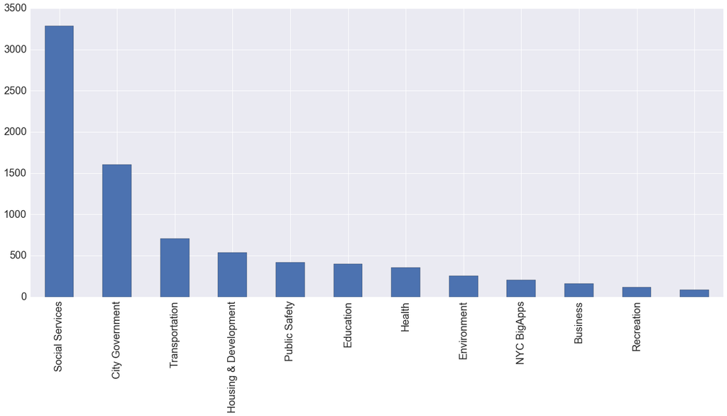

```python
_.plot(kind='bar', figsize=(24, 10), fontsize=20)
```

**Tables**

```python
endpoint_categories(tabular_datasets).value_counts()
```

```
City Government          260
Education                224
Housing & Development    141
Public Safety            130
Social Services           88
Environment               61
Transportation            49
Business                  42
Recreation                31
Health                    23
                          17
NYC BigApps                7
dtype: int64
```

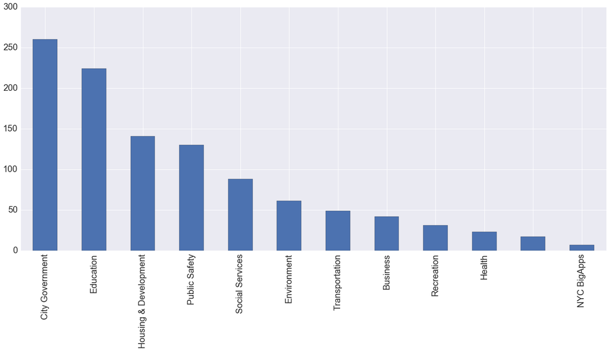

```python
_.plot(kind='bar', figsize=(24, 10), fontsize=20)
```

**Reliability**

These counts are known to be reliable insofar as simple categorization is reliable.

### Update Automation

```python
pd.Series({2: 'Yes', 1: None})
```

```
1    None
2     Yes
dtype: object
```

```python
def endpoint_automations(endpoints):
    """
    Returns a pd.Series mapping endpoints to their automation type.
    """
    def get_update_automation_type(endpoint):
        # Get the "domain metadata".
        domain_metadata = endpoint['classification']['domain_metadata']
        # Format example:
        # [{'key': 'Update_Automation', 'value': 'Yes'},
        #  {'key': 'Update_Update-Frequency', 'value': 'Daily'},
        #  {'key': 'Dataset-Information_Agency', 'value': 'Department of Buildings (DOB)'}]
        #
        # If Update_Automation is included it should be *first* entry.
        # But we don't want to just check for that! Because this could change in the future.
        # Instead we need to implement a search strategy.
        # First get all_keys.
        all_keys = [d['key'] for d in domain_metadata]
        # Then try to get the index. This raises a ValueError if it doesn't find anything---return None in that case.
        try:
            # If we didn't fail and return None, pick and return it.
            return domain_metadata[all_keys.index("Update_Automation")]['value']
        except ValueError:
            return None

    return pd.Series(map(get_update_automation_type, endpoints))
```

**Endpoints**

```python
endpoint_automations(endpoints).value_counts(dropna=False)
```

```
NaN    6826
Yes     931
No      388
dtype: int64
```

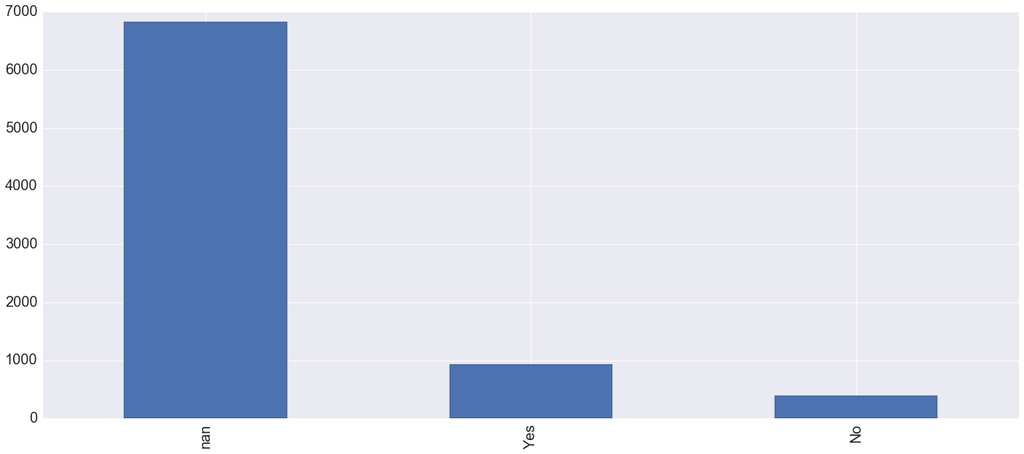

```python
_.plot(kind='bar', figsize=(24, 10), fontsize=20)
```

**Tables**

```python
endpoint_automations(tabular_datasets).value_counts(dropna=False)
```

```
NaN    796
No     153
Yes    124
dtype: int64
```

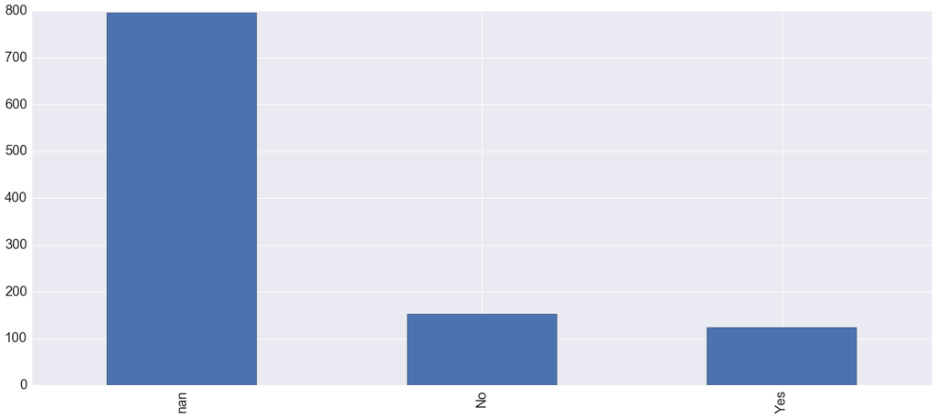

```python
_.plot(kind='bar', figsize=(24, 10), fontsize=20)
```

### Update Frequency

```python
def endpoint_update_frequency(endpoints):
    """
    Returns a pd.Series mapping endpoints to their update frequencies.
    """
    def get_update_frequency(endpoint):
        # Get the "domain metadata".
        domain_metadata = endpoint['classification']['domain_metadata']
        # Format example:
        # [{'key': 'Update_Automation', 'value': 'Yes'},
        #  {'key': 'Update_Update-Frequency', 'value': 'Daily'},
        #  {'key': 'Dataset-Information_Agency', 'value': 'Department of Buildings (DOB)'}]
        #
        # First get all_keys.
        all_keys = [d['key'] for d in domain_metadata]
        # Then try to get the index. This raises a ValueError if it doesn't find anything---return None in that case.
        try:
            # If we didn't fail and return None, pick and return it.
            return domain_metadata[all_keys.index("Update_Update-Frequency")]['value']
        except ValueError:
            # Otherwise throw out a None.
            return None

    return pd.Series(list(map(get_update_frequency, endpoints)))
```

**Endpoints**

```python
endpoint_update_frequency(endpoints).value_counts(dropna=False)
```

```
Daily                       4564
As needed                   1273
Annually                     550
Monthly                      464
Historical Data              426
Weekdays                     332
NaN                          262
Weekly                        76
Quarterly                     68
Biannually                    53
Several times per minute      44
Biweekly                      16
2 to 4 times per year          7
Bimonthly                      4
                               3
Unknown                        2
Annually                       1
dtype: int64
```

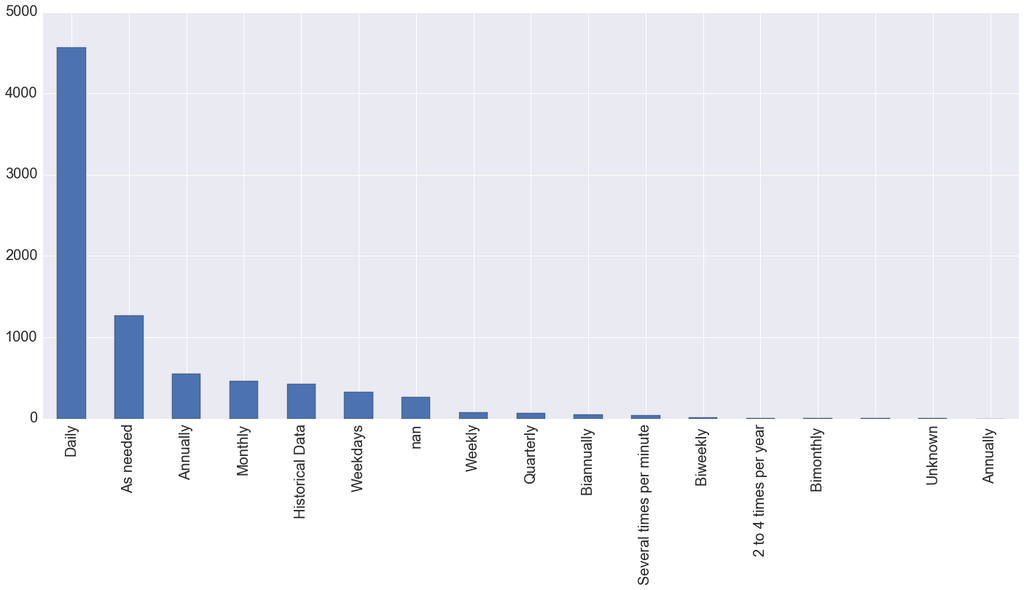

```python
_.plot(kind='bar', figsize=(24, 10), fontsize=20)
```

**Tables**

```python
endpoint_update_frequency(tabular_datasets).value_counts(dropna=False)
```

```
Annually                    333
As needed                   235
NaN                         149
Historical Data             138
Monthly                      76
Daily                        47
Biannually                   30
Weekly                       29
Quarterly                    22
Weekdays                      4
Bimonthly                     3
                              3
Biweekly                      1
Unknown                       1
Annually                      1
Several times per minute      1
dtype: int64
```

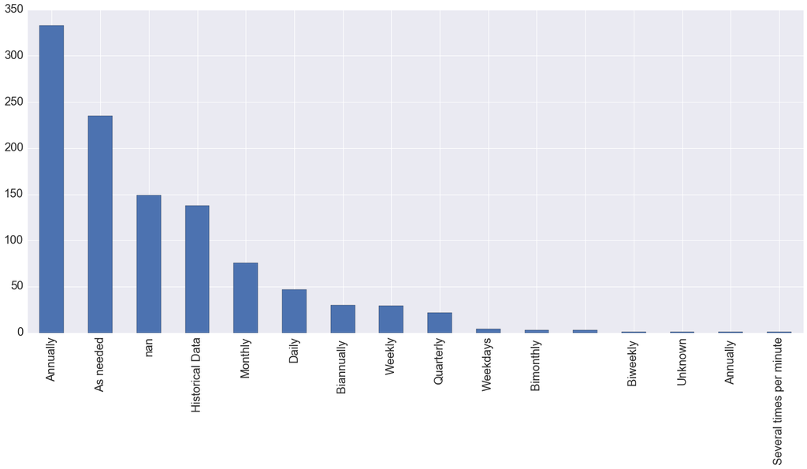

```python
_.plot(kind='bar', figsize=(24, 10), fontsize=20)
```

What's that one updated several times per minute?

```python
tabular_hashes = pd.Series([d['permalink'].split("/")[-1] for d in tabular_datasets])

tabular_hashes[endpoint_update_frequency(tabular_datasets) == 'Several times per minute']
```

```
29    tdsx-cvye
dtype: object
```

Oh. Go figure.

### Dataset Ownership

Note: this uses `information_agency` under `domain_metadata`. There's also `resource_attribution` under `resource`, but that seems to be a lot less clean—doing things like substiting `NYPD` for `New York Police Department (NYPD)`, for example. Though I believe technically these fields are a little different—one is who *provided* the dataset, one is who *made* it—but I think it makes little real difference one way or the other.

```python
def endpoint_ownership(endpoints):
    """
    Returns a pd.Series mapping endpoints to their update frequencies.
    """
    def get_endpoint_owner(endpoint):
        # Get the "domain metadata".
        domain_metadata = endpoint['classification']['domain_metadata']
        # Format example:
        # [{'key': 'Update_Automation', 'value': 'Yes'},
        #  {'key': 'Update_Update-Frequency', 'value': 'Daily'},
        #  {'key': 'Dataset-Information_Agency', 'value': 'Department of Buildings (DOB)'}]
        #
        # First get all_keys.
        all_keys = [d['key'] for d in domain_metadata]
        # Then try to get the index. This raises a ValueError if it doesn't find anything---return None in that case.
        try:
            # If we didn't fail and return None, pick and return it.
            return domain_metadata[all_keys.index("Dataset-Information_Agency")]['value']
        except ValueError:
            # Otherwise throw out a None.
            return None

    return pd.Series(list(map(get_endpoint_owner, endpoints)))
```

```python
endpoint_ownership(endpoints).value_counts(dropna=False)
```

```
311                                                                    3096
Taxi and Limousine Commission (TLC)                                     497
Office of Administrative Trials and Hearings (OATH)                     495
Department of Finance (DOF)                                             446
Police Department (NYPD)                                                358
Department of Health and Mental Hygiene (DOHMH)                         337
Department of Education (DOE)                                           318
Department of City Planning (DCP)                                       231
Department of Citywide Administrative Services (DCAS)                   223
Department of Buildings (DOB)                                           202
Department of Information Technology & Telecommunications (DoITT)       180
Metropolitan Transportation Authority (MTA)                             169
Department of Parks and Recreation (DPR)                                134
Civilian Complaint Review Board (CCRB)                                  126
New York City Housing Authority (NYCHA)                                 102
Other                                                                    87
Department of Youth and Community Development (DYCD)                     77
School Construction Authority (SCA)                                      73
Department of Environmental Protection (DEP)                             72
Mayor's Office of Long-Term Planning and Sustainability (OLTPS)          57
Department of Sanitation (DSNY)                                          54
Department of Transportation (DOT)                                       49
Department of Probation (DOP)                                            44
Human Resources Administration (HRA)                                     42
Office of the Mayor (OTM)                                                41
Mayor's Office of Long Term Planning and Sustainability (OLTPS)          38
NaN                                                                      36
Department of Consumer Affairs (DCA)                                     36
Mayor's Office of Data Analytics (MODA)                                  33
Office of Emergency Management (OEM)                                     30
                                                                       ...
New York Public Library (NYPL)                                            8
Landmarks Preservation Commission (LPC)                                   8
Department of Information Technology and Telecommunications (DoITT)       8
Department of Cultural Affairs (DCLA)                                     7
Brooklyn Public Library (BPL)                                             7
Department of Records and Information Services (RECORDS)                  7
Manhattan Borough President (MBPO)                                        7
Law Department (LAW)                                                      6
Office of Payroll Administration (OPA)                                    6
Office of Film, Theatre, and Broadcasting (FILM)                          5
Commission on Women's Issues (CWI)                                        5
Latin Media & Entertainment Commission (LMEC)                             5
Mayor's Office to Combat Domestic Violence (OCDV)                         5
NYC Service (NYCSERVICE)                                                  4
New York City Tax Commission (TAXCOMM)                                    4
Mayor's Office of Sustainability (MOS)                                    3
Office of Citywide Event Coordination and Management (CECM)               2
Conflicts of Interest Board (CONFLICTS)                                   2
NYC Media (MEDIA)                                                         2
NYC & Company (NYCGO)                                                     2
Police Pension Fund (NYCPPF)                                              2
Independent Budget Office (IBO)                                           2
Board of Elections (BOENY)                                                2
CitiBike                                                                  2
Queens Library (QBPL)                                                     2
Enigma                                                                    1
City University of New York (CUNY)                                        1
Office of the Comptroller (COMPTROLLER)                                   1
Twilio                                                                    1
Mayor's Office of Adult Education (ADULTED)                               1
dtype: int64
```

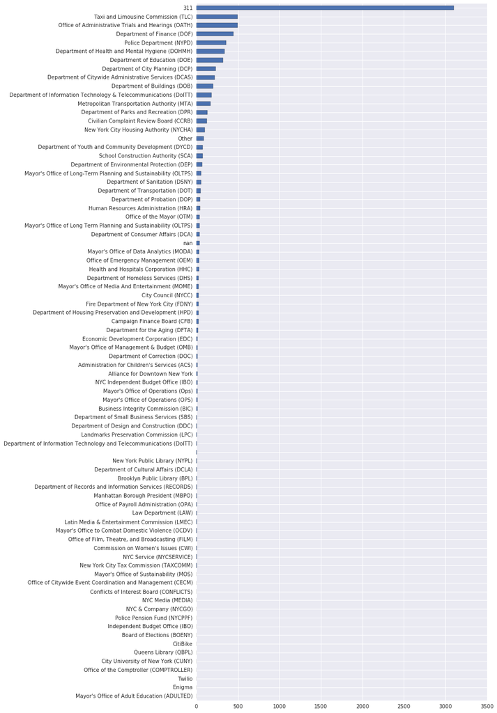

```python
_.sort_values(ascending=True).plot(kind='barh', figsize=(10, 24))
```

```python
endpoint_ownership(tabular_datasets).value_counts(dropna=False)
```

```
Department of Education (DOE)                                        179
Civilian Complaint Review Board (CCRB)                               119
Department of Finance (DOF)                                           69
School Construction Authority (SCA)                                   44
Taxi and Limousine Commission (TLC)                                   40
Department of Probation (DOP)                                         40
Department of Environmental Protection (DEP)                          40
Human Resources Administration (HRA)                                  36
Department of Youth and Community Development (DYCD)                  36
Department of City Planning (DCP)                                     31
Office of the Mayor (OTM)                                             23
Department of Buildings (DOB)                                         23
Department of Information Technology & Telecommunications (DoITT)     22
New York City Housing Authority (NYCHA)                               22
Department of Citywide Administrative Services (DCAS)                 21
Other                                                                 21
Department of Housing Preservation and Development (HPD)              19
Fire Department of New York City (FDNY)                               15
Department of Sanitation (DSNY)                                       14
Department of Health and Mental Hygiene (DOHMH)                       14
Mayor's Office of Management & Budget (OMB)                           13
Department of Homeless Services (DHS)                                 13
Campaign Finance Board (CFB)                                          13
Department of Parks and Recreation (DPR)                              12
NYC Independent Budget Office (IBO)                                   12
NaN                                                                   11
Department of Correction (DOC)                                        10
Mayor's Office of Operations (OPS)                                     9
Department of Consumer Affairs (DCA)                                   9
                                                                       8
                                                                    ...
Business Integrity Commission (BIC)                                    5
Department of Design and Construction (DDC)                            5
Mayor's Office of Long-Term Planning and Sustainability (OLTPS)        5
Alliance for Downtown New York                                         4
New York Public Library (NYPL)                                         4
Department of Records and Information Services (RECORDS)               4
Office of Administrative Trials and Hearings (OATH)                    4
Landmarks Preservation Commission (LPC)                                3
Office of Payroll Administration (OPA)                                 3
Department for the Aging (DFTA)                                        3
Mayor's Office of Media And Entertainment (MOME)                       3
Mayor's Office of Sustainability (MOS)                                 3
Economic Development Corporation (EDC)                                 3
Mayor's Office of Operations (Ops)                                     2
Police Pension Fund (NYCPPF)                                           2
Independent Budget Office (IBO)                                        2
Board of Elections (BOENY)                                             2
Office of Film, Theatre, and Broadcasting (FILM)                       2
Latin Media & Entertainment Commission (LMEC)                          2
New York City Tax Commission (TAXCOMM)                                 2
Police Department (NYPD)                                               2
Mayor's Office of Data Analytics (MODA)                                1
Queens Library (QBPL)                                                  1
Office of Citywide Event Coordination and Management (CECM)            1
NYC Service (NYCSERVICE)                                               1
Conflicts of Interest Board (CONFLICTS)                                1
Commission on Women's Issues (CWI)                                     1
Administration for Children's Services (ACS)                           1
Brooklyn Public Library (BPL)                                          1
Mayor's Office of Adult Education (ADULTED)                            1
dtype: int64
```

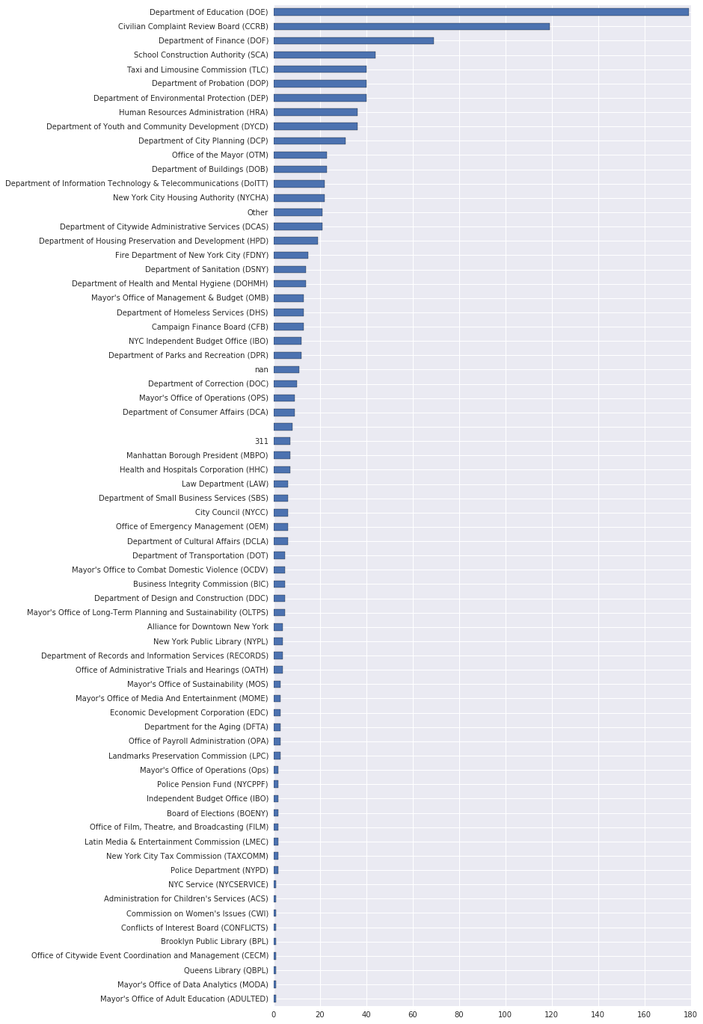

```python
_.sort_values(ascending=True).plot(kind='barh', figsize=(10, 24))
```

### Creation Date

```python
def endpoint_creation_dates(endpoints):
    """
    Returns a pd.Series mapping endpoints to their creation times.
    """
    return pd.to_datetime(pd.Series(list(map(lambda d: d['resource']['createdAt'], endpoints))))
```

**Endpoints**

What is the first-ever endpoint?

```python
endpoint_creation_dates(endpoints).sort_values().head(5)
```

```
237   2010-11-03 17:15:45
40    2011-07-26 16:26:28
87    2011-07-26 19:48:24
86    2011-07-26 19:56:27
962   2011-07-26 19:59:04
dtype: datetime64[ns]
```

```python
endpoints[endpoint_creation_dates(endpoints).sort_values().index[0]]['resource']['id']
```

```
'xszr-btpb'
```

> Electronics Stores

> A list of electronics stores that have a current DCA license as of the run date.

Well that's weird. The time lag between the first entry and the last one is also very strange.

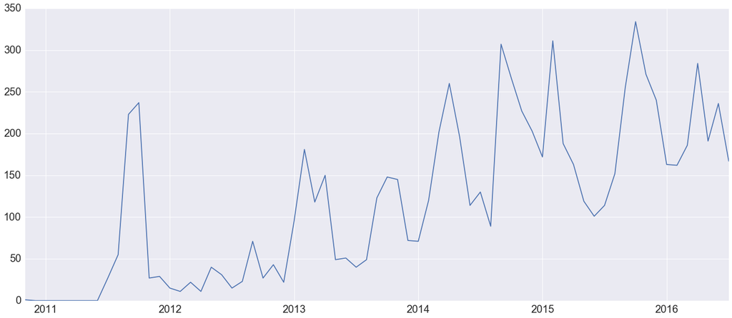

```python
# Monthly endpoint creation
pd.Series(range(len(endpoints)), index=endpoint_creation_dates(endpoints).values).resample('M').count().plot(figsize=(24, 10),
                                                                                                             fontsize=20)
```

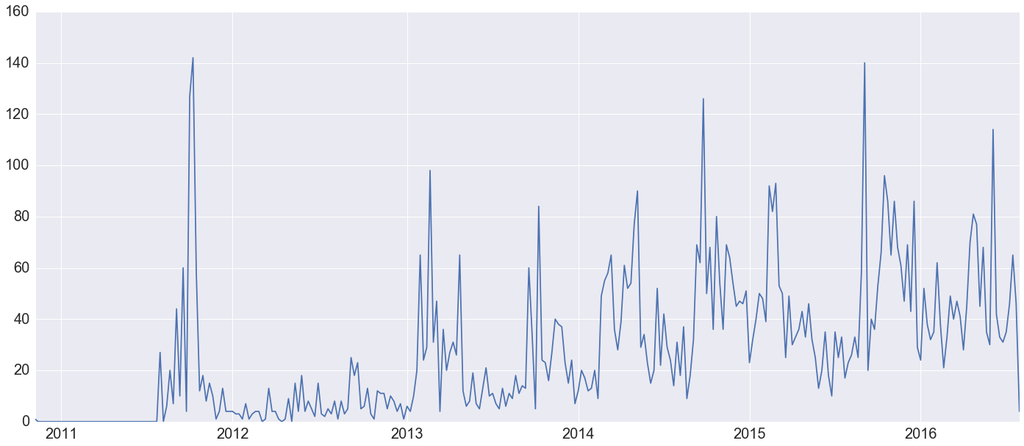

```python
# Weekly endpoint creation
pd.Series(range(len(endpoints)), index=endpoint_creation_dates(endpoints).values).resample('W').count().plot(figsize=(24, 10),
                                                                                                             fontsize=20)
```

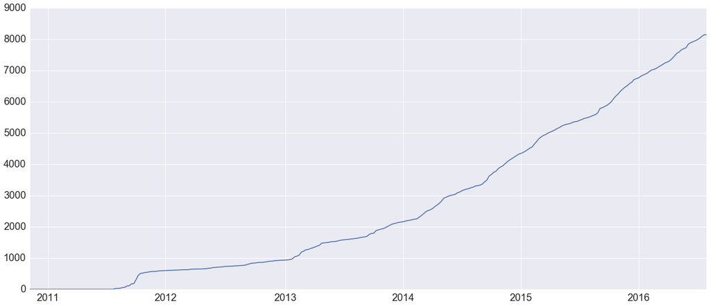

```python
# Cumulative endpoint count.
pd.Series(range(len(endpoints)), index=endpoint_creation_dates(endpoints).values).resample('W').count().cumsum().plot(figsize=(24, 10), fontsize=20)
```

**Tables**

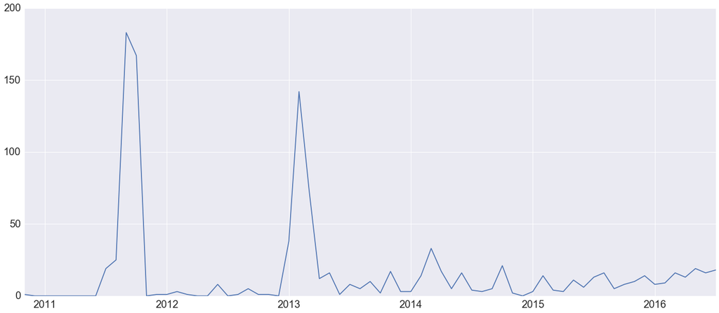

```python
# Monthly tabular dataset creation
pd.Series(range(len(tabular_datasets)), index=endpoint_creation_dates(tabular_datasets).values).resample('M').count().plot(figsize=(24, 10),
                                                                                                                           fontsize=20)
```

The trend is moderately upwards, but the graph as a whole is dominated by a couple of really big publication dates:

```python
pd.Series(range(len(tabular_datasets)), index=endpoint_creation_dates(tabular_datasets).values).resample('M').count().sort_values(ascending=False)
```

```
2011-09-30    183
2011-10-31    167
2013-02-28    142
2013-03-31     73
2013-01-31     38
2014-03-31     33
2011-08-31     25
2014-10-31     21
2016-05-31     19
2011-07-31     19
2016-07-31     18
2013-11-30     17
2014-04-30     17
2014-06-30     16
2015-08-31     16
2013-05-31     16
2016-06-30     16
2016-03-31     16
2015-02-28     14
2015-12-31     14
2014-02-28     14
2016-04-30     13
2015-07-31     13
2013-04-30     12
2015-05-31     11
2013-09-30     10
2015-11-30     10
2016-02-29      9
2012-06-30      8
2015-10-31      8
             ...
2015-03-31      4
2015-01-31      3
2015-04-30      3
2013-12-31      3
2014-01-31      3
2014-08-31      3
2012-02-29      3
2013-10-31      2
2014-11-30      2
2012-03-31      1
2011-12-31      1
2012-01-31      1
2012-08-31      1
2010-11-30      1
2012-10-31      1
2012-11-30      1
2013-06-30      1
2011-05-31      0
2010-12-31      0
2011-01-31      0
2011-02-28      0
2011-03-31      0
2011-04-30      0
2012-04-30      0
2011-06-30      0
2012-05-31      0
2012-12-31      0
2011-11-30      0
2012-07-31      0
2014-12-31      0
dtype: int64
```

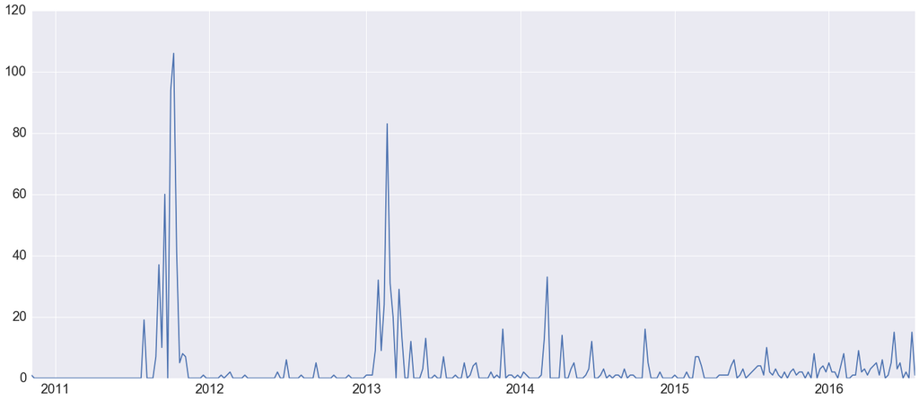

```python
# Weekly endpoint creation
pd.Series(range(len(tabular_datasets)), index=endpoint_creation_dates(tabular_datasets).values).resample('W').count().plot(figsize=(24, 10),
                                                                                                                           fontsize=20)
```

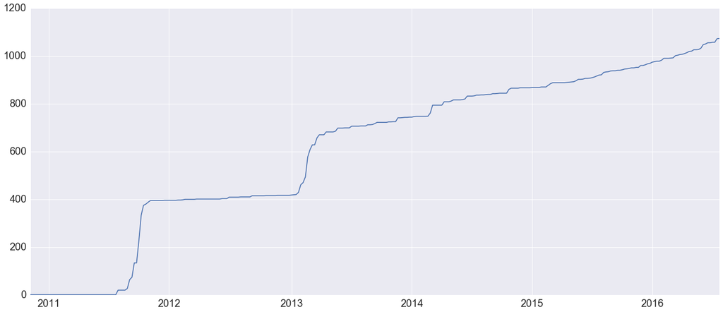

```python
# Cumulative endpoint count.
pd.Series(range(len(tabular_datasets)), index=endpoint_creation_dates(tabular_datasets).values).resample('W').count().cumsum().plot(figsize=(24, 10), fontsize=20)
```

### Updated-ness

```python
def endpoint_update_dates(endpoints):
    """
    Returns a pd.Series mapping endpoints to their update dates.
    """
    return pd.to_datetime(pd.Series(list(map(lambda d: d['resource']['updatedAt'], endpoints))))
```

**Endpoints**

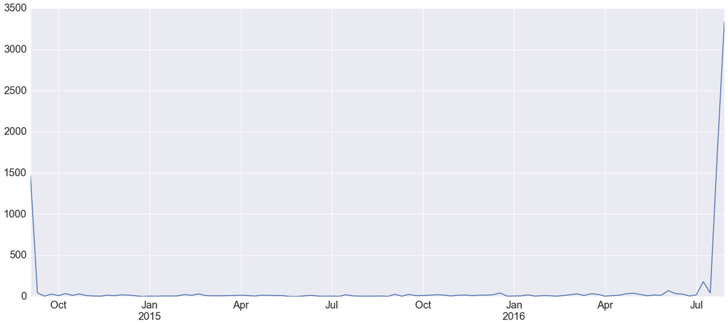

```python
# Endpoints by weekly update recentness.
pd.Series(range(len(endpoints)), index=endpoint_update_dates(endpoints).values).resample('W').count().plot(figsize=(24, 10), fontsize=20)
```

```python
sorted(endpoint_update_dates(endpoints).values)[0]
```

```
numpy.datetime64('2014-09-05T16:57:38.000000000')
```

Every endpoint was updated at least since September 2014, which seems to imply that there was some software update at around that time which touched and reset this field on every item in the portal. Update history since then is extremely sparse, which makes sense—everything more recent than a few weeks old is static or irregularly updated data. The recent hump is things that are "current".

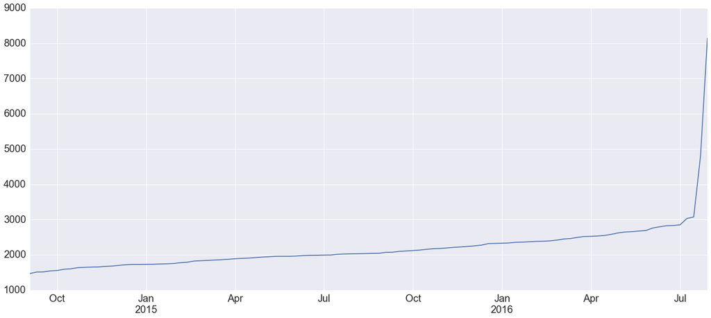

```python
pd.Series(range(len(endpoints)), index=endpoint_update_dates(endpoints).values).resample('W').count().cumsum().plot(figsize=(24, 10), fontsize=20)
```

**Tables**

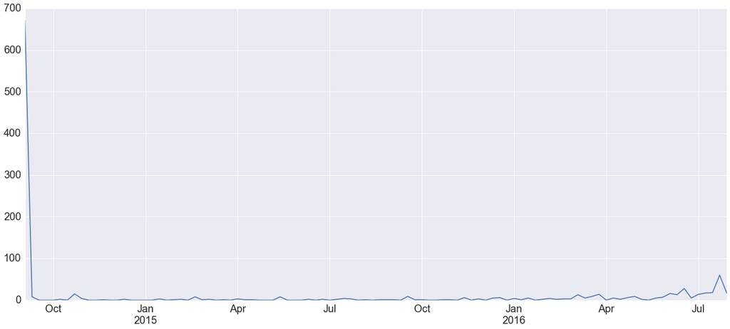

```python
# Weekly updatedAt dates.
pd.Series(range(len(tabular_datasets)), index=endpoint_update_dates(tabular_datasets).values).resample('W').count().plot(figsize=(24, 10), fontsize=20)
```

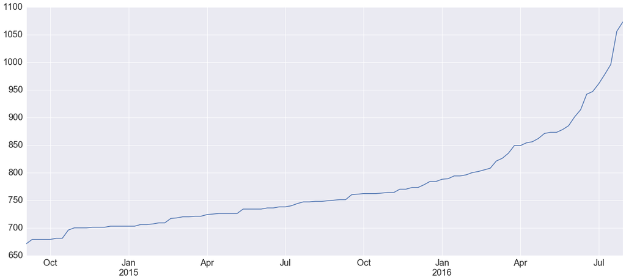

```python
# Weekly updatedAt dates, cumulative.
pd.Series(range(len(tabular_datasets)), index=endpoint_update_dates(tabular_datasets).values).resample('W').count().cumsum().plot(figsize=(24, 10), fontsize=20)
```

This plot is more meaningful if we invert. The following plot asks the question: how many datasets were updated in at least the $n$ most recent weeks? This allows us to actually vet the update frequency we are given in the related field against the reality of the Open Data update cycle.

(Note that because of the update issue mentioned above it's not possible to look any further back.)

```python
backwards_facing_cumsum = (len(tabular_datasets) - pd.Series(range(len(tabular_datasets)), index=endpoint_update_dates(tabular_datasets).values).resample('W').count().cumsum())
backwards_facing_cumsum.index = range(len(backwards_facing_cumsum))[::-1]
```

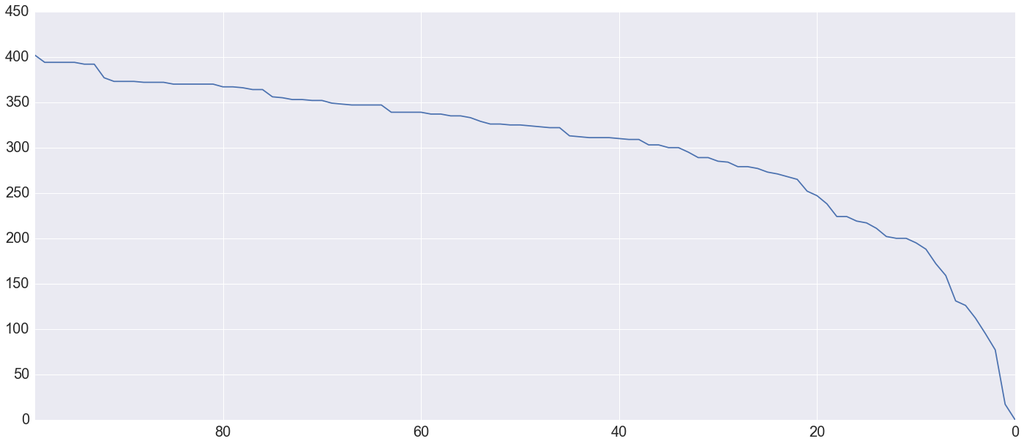

```python
backwards_facing_cumsum.plot(figsize=(24, 10), fontsize=20)
```

### Page views

```python
def endpoint_monthy_page_views(endpoints):
    """
    Returns a pd.Series mapping endpoints to their monthly page views.
    """
    return pd.Series(list(map(lambda srs: srs['resource']['view_count']['page_views_last_month'], endpoints)))
```

**Endpoints**

```python
endpoint_monthy_page_views(endpoints).sort_values(ascending=False)
```

```
0       167921
21       18697
3        13908
1        12959
6        11463
2         5866
112       3038
4         2897
11        2497
12        2406
5         2220
14        2215
88        2138
168       2120
157       2116
```

[output cut: 47 more lines]

Unsurprisingly (if you're familiar with these things) the result roughly follows [Zipf's law](https://en.wikipedia.org/wiki/Zipf%27s_law), so it has to be visualized as a log plot.

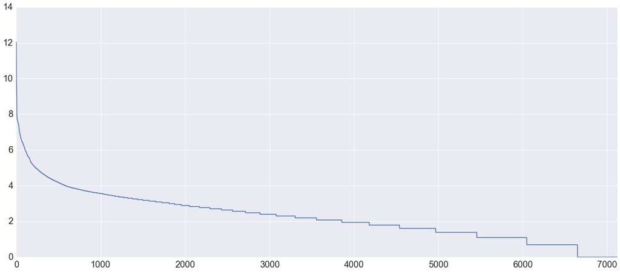

```python
pd.Series(np.log([val for val in endpoint_monthy_page_views(endpoints).sort_values(ascending=False).values if val != 0])).plot(figsize=(24, 10), fontsize=20)
```

**Tables**

No different.

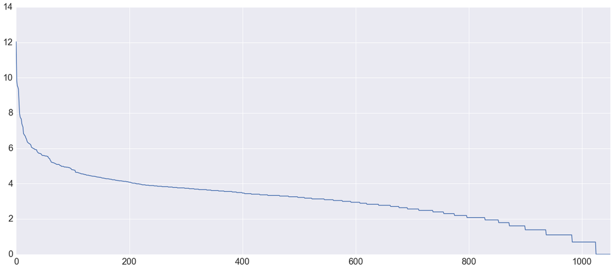

```python
pd.Series(np.log([val for val in endpoint_monthy_page_views(tabular_datasets).sort_values(ascending=False).values if val != 0])).plot(figsize=(24, 10), fontsize=20)
```

### Resource Type

```python
def endpoint_types(endpoints):
    """
    Returns a pd.Series mapping endpoints to their update dates.
    """
    return pd.Series(list(map(lambda d: d['resource']['type'], endpoints)))
```

**Endpoints**

Here, `dataset==table`.

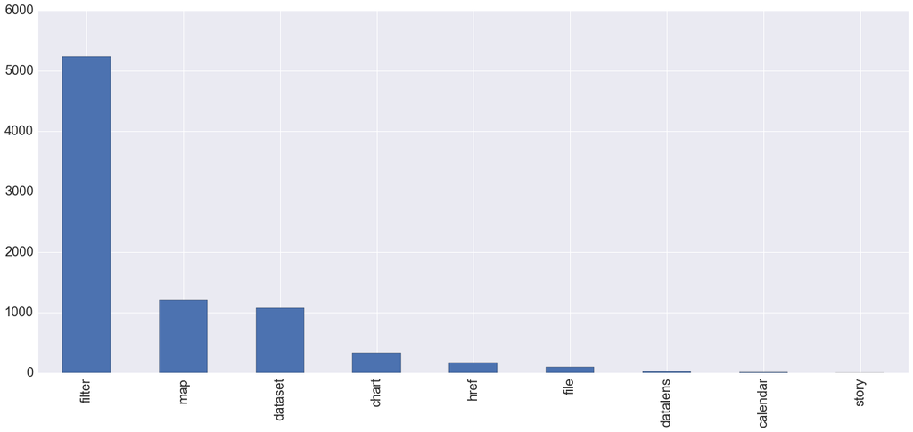

```python
endpoint_types(endpoints).value_counts().plot(kind='bar', figsize=(24, 10), fontsize=20)
```

Filters are dominated by topic-specific views of 311 call center data, of which there are thousands. These in turn dominate the rest of the data on the portal, at least in terms of raw counts!

### Column names

```python
def endpoint_column_names(endpoints):
    """
    Returns a pd.Series mapping endpoints to their update dates.
    """
    all_columns = []
    for endpoint in endpoints:
        all_columns += endpoint['resource']['columns_name']
    return pd.Series(all_columns)
```

```python
len(endpoint_column_names(endpoints))
```

```
216952
```

```python
len(endpoint_column_names(tabular_datasets))
```

```
15719
```

Deeper exploration of this requires applying NLP to it.